# COVID19 - Forecast and predictions using a time dependent SEIR model - Italy

Paolo Girardi

21 Marzo, 2020

This work is licensed under a [Creative Commons Attribution-NonCommercial 4.0 International License](http://creativecommons.org/licenses/by-nc/4.0/).

# Disclaimer

- We want to investigate the evolution of the coronavirus pandemic in Italy from a statistical perspective using aggregated data.
- Our point of view is that of surveillance with the goal of detecting important changes in the underlying (random) process as soon as possible after it has occured.
- We use data provided by Italian Civil Protection Department
- This document is in a draft mode, and it is continuously updated.
- The layout of the draft must definitely be improved.

*NB: set the file output format to

#output:html_document:  
df_print: paged  
pdf_document:  
toc: yes

which performs the same analysis enabling Javascript Pictures.

## The COVID dataset

The present analysis started from the dataset on COVID19 updated in https://github.com/pcm-dpc/COVID-19, database provided by the Italian Civil Protection.

# Software

Install packages `dygraphs`, `xts` and `EpiDynamics` if not available

```r
checkpackage <- function(package) {
  if (!package %in% installed.packages()) install.packages(package)
}
checkpackage("dygraphs")
checkpackage("xts")
checkpackage("EpiDynamics")
checkpackage("webshot")
checkpackage("bsts")
checkpackage("ggplot2")
```

and load them.

# Source of the data

Download the data from

https://github.com/pcm-dpc/COVID-19/

# Results

## Load dataset

```
## [1] 26
```

Several outcomes can be potentially monitored, that is

```
##  [1] "ricoverati_con_sintomi"      "terapia_intensiva"
##  [3] "totale_ospedalizzati"        "isolamento_domiciliare"
##  [5] "totale_attualmente_positivi" "nuovi_attualmente_positivi"
##  [7] "dimessi_guariti"             "deceduti"
##  [9] "totale_casi"                 "tamponi"
```

It is worth noting that some outcomes present negative counts in some regions. It looks like some of these negative counts are redesignations. Outcomes presenting negative values cannot be analyzed using the proposed model.

Then we extract the timeseries.

[interactive chart not shown]

### The S(E)IR model (to be revised)

With the aim of predicting the future number of COVID19 cases on the basis of the actual data, we used a SEIR model applied to the COVID19 epidemic to Italy

We will consider the classical [SIR model](https://en.wikipedia.org/wiki/Compartmental_models_in_epidemiology) [@Kermack1927].

The model divides a population of hosts into three classes: susceptible, infected, recovered. The model describes how the portion of the population in each of these classes changes with time. Births are modeled as flows from “elsewhere” into the susceptible class; deaths are modeled as flows from the $S$, $I$, or $R$ compartment into “elsewhere”. If $S$, $I$, and $R$ refer to the numbers of individuals in each compartment, then these **state variables** change according to the following system of differential equations:
$$\begin{aligned}
\frac{d}{dt}S(t) &= B(t)-\lambda\,S(t)-\mu\,S(t)\\
\frac{d}{dt}I(t) &= \lambda\,S(t)-\gamma\,I(t)-\mu\,I(t)\\
\frac{d}{dt}R(t) &= \gamma\,I(t)-\mu\,R(t).\\
\end{aligned}$$
Here, $B$ is the crude birth rate (births per unit time), $\mu$ is the death rate and $\gamma$ is the recovery rate. We’ll assume that the force of infection, $\bet$, for a constant population $N$
$$\lambda = \beta\,\frac{I}{N},$$
so that the risk of infection a susceptible faces is proportional to the *prevalence* (the fraction of the population that is infected). This is known as the assumption of frequency-dependent transmission.

# The reproduction number of COVID19.

The number of infected individuals $I$ at time $t$ is approximately
$$I(t)\;\approx\;I_0\,e^{(R_0-1)\,(\gamma+\mu)\,t}$$
where $I_0$ is the (small) number of infectives at time $0$, $\frac{1}{\gamma}$ is the infectious period, and $\frac{1}{\mu}$ is the host lifespan.

$R_0$ is the reproduction number (https://en.wikipedia.org/wiki/Basic_reproduction_number) and indicates how contagious an infectious disease is.

Taking logs of both sides, we get

$$\log{I}(t)\;\approx\;\log{I_0}+(R_0-1)\,(\gamma+\mu)\,t,$$
which implies that a semi-log plot of $I$ vs $t$ should be approximately linear with a slope proportional to $R_0$ and the recovery rate.

[interactive chart not shown]

We estimate the $R_0$ parameter in the linear model.

$$\log(I(t))= \beta_0 + \beta_1 t +e_t.$$

The estimated slope coefficient $\hat\beta_1$ is used to estimate $R_0$ as in the following formula:

$$\widehat\beta_1=(\widehat{R_0}-1)\,(\gamma+\mu)$$
The parameter $\mu$<<$\gamma$ and it can not be considered. As consequence, R0 can be estimated as follows
$$\hat{R_0}=1+\frac{\hat{\beta_1}}{\gamma}$$
Respect to the SIR model, $R_0$ can be estimated as follows:
$$\hat{R_0}=\frac{\hat{\beta}}{\gamma}$$
And this was we can retrive the value of $\beta$ in the SEIR model by means of
$$\hat{R_0}=\frac{\hat{\beta}}{\gamma}=1+\frac{\hat{\beta_1}}{\gamma}\\
\hat{\beta}=(1+\frac{\hat{\beta_1}}{\gamma})*{\gamma}={\gamma}+\hat{\beta}_1$$
where $\beta_1$ is the slope coefficient. \

The incubation period for the coronavirus is in mean 5.1 days with a range from 2-14 days. Please see https://www.worldometers.info/coronavirus/coronavirus-incubation-period/. However, the incubation period is used for epidemic diseases that causes the immediate home isolation of infected subjects. The duration of the diseases is about 2 weeks.

However, in the calculation of R0 we considered an infectious period of 21 days for two reasons:  
1) the majority of cases is asymptomatic; 2) 21 days is the worst scenario because in this period COVID19 symptoms can be confused with the concomitant FLU epidemic (https://www.webmd.com/lung/news/20200310/know-the-symptoms-of-covid19).

We calculate several R0 values, each one based on a mobile window of 5 days, that can be sufficient to estimate a local trend, in order to assess if the R0 trend is decreasing (how is expected to be). In this way, the R0 for the first and the last two days of observation is impossibile to estimate.

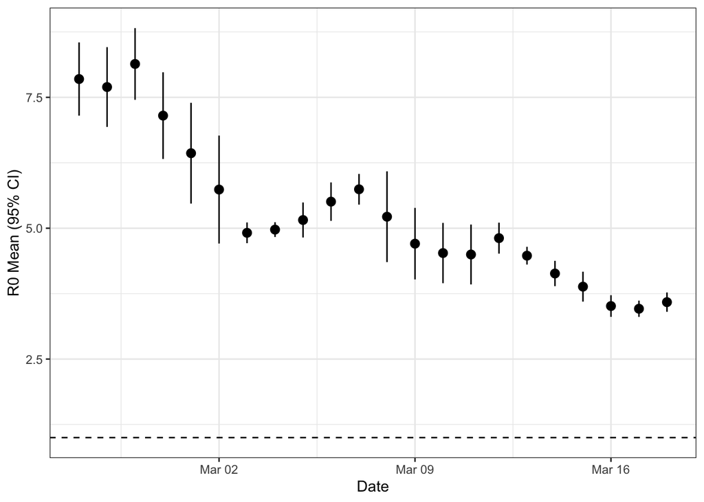

The R0 shows a decreasing trend in the last period. We use the estimated trend between R0 and time to calculate the future R0 value for the next 14 days. We predict beta (and R0) for the next 14 days by means of a linear regressione model, assuming a Normal distribution for the beta (the slope).

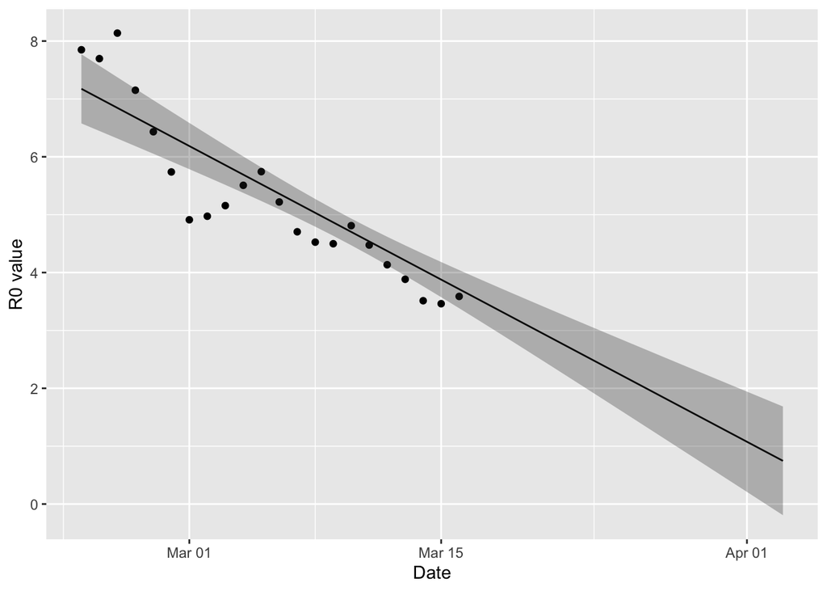

R0 passes from a value of 7.85 in the initial phase to an estimated value of 0.75 at the ending of the 14-days forecast.  
We use the library(EpiDynamics) and the function SEIR() to implement a SEIR model:

$$\begin{aligned}
\frac{d}{dt}S(t) &= \mu (N-S)-\beta \frac{SI}{N}-\nu S\\
\frac{d}{dt}E(t) &= \beta \frac{SI}{N}-(\mu+\sigma) E \\
\frac{d}{dt}I(t) &=\sigma E- (\mu+\gamma)I \\
\frac{d}{dt}R(t) &= \gamma\,I(t)-\mu\,R(t)+\nu S.\\
\end{aligned}$$

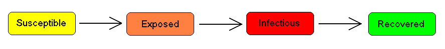

Respect to the previous formulation, the compartment of exposed people (E) was inserted between the susceptible and infected compartments.  
(https://en.wikipedia.org/wiki/Bayesian_structural_time_series). The parameter $\nu$ is the rate of vaccination.

We want to make a short term forecast (14 days).

We made a forecast by means of a SEIR model fixing a series of initial status: *S:N, the size of Italian population*  
E: The number of exposed people (unknown)  
*I_start: initial number of COVID-19 cases*  
R_start: initial number of recovered

and parameters:  
- beta: gamma + slope - gamma= 1/duration of diseases (duration=21 days) - sigma: the coronavirus transmission rate - mu0: the overall mortality rate

```r
# initial number of infectus
I_start<-dat_csv$totale_attualmente_positivi[dim(dat_csv)[1]]; I_start
```

```
## [1] 37860
```

```r
# initial number of recovered, based on the proportion of discharged from the health services
prop<-dat_csv$dimessi_guariti[dim(dat_csv)[1]]/dat_csv$totale_ospedalizzati[dim(dat_csv)[1]]
R_start<-prop*dat_csv$totale_casi[dim(dat_csv)[1]]; R_start
```

```
## [1] 12914.09
```

```r
# Italian population
N=60480000
# duration of COVID19 as the sum of incubation (5-14 days) and the duration of diseases (about 20 days)
duration<-21
#mortality rate
mu0<-1/(82*365.25) # 1/lifespan
```

We try to estimates sigma (from exposed to infected) and the number of exposed population on the basis of the last 5 days of observed number of total infected people.

We suppose that the number of total infected $I(t)$ can be the realization of a Poisson random variable
$$I(t) \sim Poisson (\theta_t)$$
where $\theta_t$ is the unknown mean of the random process at the time $t$.

The Poisson distribution has a fixed variance that is equal to the mean; in the next part we try to estimates the parameters considering a Negative Binomial distribution which allows for overdispersion.

However, the parameter $\theta_t$ can be supposed to be a realization of a SEIR model with initial parameters $\theta=(\mu,\beta,\sigma, \gamma)$ and initial status $S=(S_{start},E_{start},I_{start},R_{start})$.

The parameter $\sigma$ and the fraction of exposed people ($E_{start}$) are our parameters of interest; we estimate $\sigma$ and $E_{start}$ minimizing the log likelihood of the described Poisson distribution (or Negative Binomial one).

```r
# number of the last considered days for calibration
last<-5
#I_start
I_1<-dat_csv$totale_attualmente_positivi[(days-last)]
#R_start
R_1<-prop*dat_csv$totale_casi[(days-last)]
#loglikelihood function
LogLikfun <- function (initials,parameters,obs) {
n<-length(obs)
N=60480000
seir_fit <- SEIR(pars = parameters, init = initials, time = 0:last)
#Poisson
#sum(dpois(x=obs[-1],lambda = seir_fit$results$I[-1]*N,log=TRUE))
#Neg Binomial
sum(dnbinom(x=obs[-1],mu=seir_fit$results$I[-1]*N,size=N,log=TRUE))
#SSE
#-sum((obs[-1]-seir_fit$results$I[-1]*N)^2)
}
### logit and its inverse for sigma
logit <- function (p) log(p/(1-p))    # the logit transform
expit <- function (x) 1/(1+exp(-x))   # inverse logit

f1<-function(par){
f_exp<-expit(par[1])
sigma<-expit(par[2])
parameters <- c(mu = mu0, beta =(mean(beta_vec[1:(days-last-4)])+1/duration), sigma = sigma, gamma =1/duration)
initials <- c(S = (1-(f_exp+I_1/N-R_start/N)), E = f_exp, I = I_1/N, R = R_1/N)
-LogLikfun(initials,parameters,dat_csv$totale_attualmente_positivi[c((days-last):days)])
}
est<-optim(fn=f1,par=c(logit(0.0005),logit(0.1)))
#estimated par
expit(est$par)
```

```
## [1] 0.000198403 0.253152210
```

```r
f_exp<-expit(est$par[1])
sigma<-expit(est$par[2])
parameters <- c(mu = mu0, beta =(mean(beta_vec[1:(days-last-4)])+1/duration), sigma = sigma, gamma = 1/duration)
initials <- c(S = (1-(f_exp+I_1/N-R_1/N)), E = f_exp, I = I_1/N, R = R_1/N)
pro<-SEIR(pars = parameters, init = initials, time = 0:last)
#predicted vs observed
cbind(pro$results$I*N,dat_csv$totale_attualmente_positivi[c((days-last):days)])
```

```
##          [,1]  [,2]
## [1,] 20603.00 20603
## [2,] 22930.77 23073
## [3,] 25795.15 26062
## [4,] 29196.05 28710
## [5,] 33155.41 33190
## [6,] 37724.71 37860
```

The values of initial parameters are

```r
#mu0
mu0;
```

```
## [1] 3.338842e-05
```

```r
#sigma
sigma
```

```
## [1] 0.2531522
```

```r
#gamma
1/duration
```

```
## [1] 0.04761905
```

```r
#mthe unknowrn fraction of exposed people is
f_exp;
```

```
## [1] 0.000198403
```

```r
#that is
f_exp/(I_1/N)
```

```
## [1] 0.582411
```

```r
#times the infected
```

For the beta parameter, we perfom a simulation on its trend by means of a Bayesian Structural Time Series using the library bsts of R.  
We estimate a BSTS model specifing a local linear trend ans 1000 simulation.

We made a forecast forward of 14 days dropping the first 100 simulation as burn-in.

```r
# Bayesian Structural Time Series
ss <- AddLocalLinearTrend(list(), beta_vec)
model1 <- bsts(beta_vec,
               state.specification = ss,
               niter = 1000)
```

[output not shown]

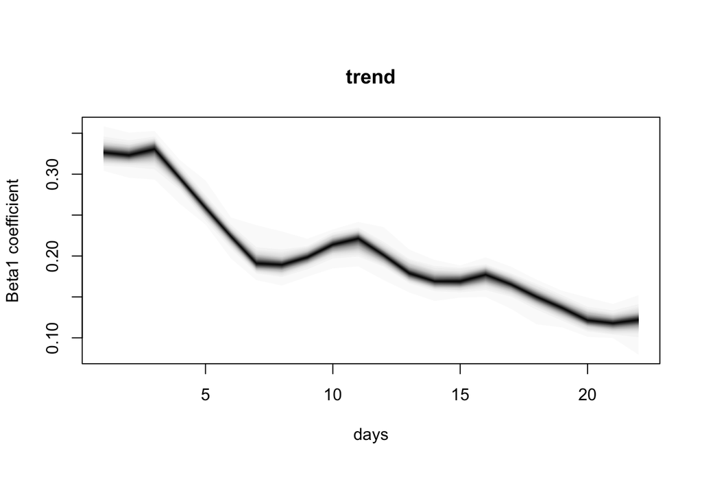

```r
par(mfrow = c(1,1))
plot(model1, "components", ylab="Beta1 coefficient", xlab="days")
```

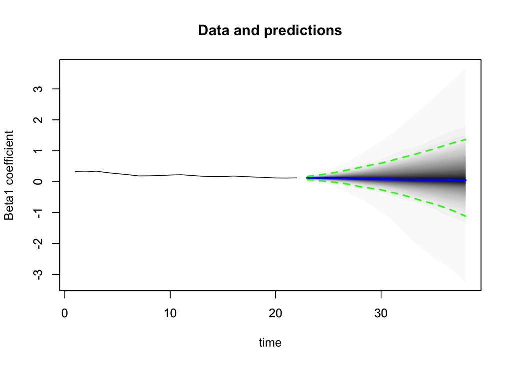

```r
#previsioni
pred1 <- predict(model1, horizon = 16, burn = 100)
par(mfrow = c(1,1))
plot(pred1 , ylab="Beta1 coefficient",main="Data and predictions")
```

```r
# matrix of beta coefficients
coef<-(pred1$distribution[,3:16])
par(mfrow = c(1,1))
```

For each vector of simulated beta coefficients we perform a SEIR model. We save the results and plot a credible interval at 50% (25-75% percentile).

```r
seir1_sim<-NULL
for(s in 1:dim(coef)[1]){
  # average number of single connections of an infected person
  # less contacts, less probability of new infections
  # we keep constant the other parameters
  forecast<-14
  seir1<-NULL
  for(i in 1:forecast){
    parameters <- c(mu = mu0, beta = (matrix(coef[s,i])+1/duration), sigma = sigma, gamma = 1/duration)
    if( i==1) initials <- c(S = 1-(f_exp+I_start/N+R_start/N), E = f_exp, I = I_start/N, R = R_start/N)
    if( i>1) initials <- c(S = seir1_temp$results$S[2], E = seir1_temp$results$E[2], I =seir1_temp$results$I[2], R = seir1_temp$results$R[2])
    seir1_temp <- SEIR(pars = parameters, init = initials, time = 0:1)
    seir1 <- rbind(seir1,SEIR(pars = parameters, init = initials, time = 0:1)$results[2,])
  }
  seir1_sim<-rbind(seir1_sim,cbind(rep(s,forecast),seir1))

}
seir1_sim[,2]<-rep(1:forecast,dim(coef)[1])
colnames(seir1_sim)[1]<-"sim"

### confidence limits
I_seir_med<-tapply(seir1_sim$I,seir1_sim$time,median)
I_seir_lwr<-tapply(seir1_sim$I,seir1_sim$time,quantile,p=0.25)
I_seir_upr<-tapply(seir1_sim$I,seir1_sim$time,quantile,p=0.75)

days.before<-date[1:days]
days.ahead<-date[(days+1):(days+forecast)]
step.ahead<-forecast+1
mu.lower<-c(dat_csv$totale_attualmente_positivi,I_seir_lwr*N)
mu.upper<-c(dat_csv$totale_attualmente_positivi,I_seir_upr*N)
mu.med<-xts(c(dat_csv$totale_attualmente_positivi,I_seir_med*N),order.by = c(days.before,days.ahead),frequency = 7)
counts<-mu.med
mu<-xts(x = as.matrix(cbind(counts,mu.lower,mu.upper)) , order.by = c(days.before,days.ahead))
p <- dygraph(mu,main=paste("Italy: Scenario  (Credible Interval ",100*0.50,"%)",sep = ""),ylab=" Infected",xlab="Day",height=400,width=800) %>%  dySeries(c("mu.lower", "counts", "mu.upper"),label="counts")
p<-p %>% dyLegend(show = "always", hideOnMouseOut = FALSE) %>%  dyShading(from = days.ahead[1], to = days.ahead[step.ahead], color = "#CCEBD6")%>% dyEvent(days.ahead[1], "Prediction", labelLoc = "bottom")
p
```

[interactive chart not shown]

The estimated (median) numbers of the current scenario by date are:

```r
S_seir_med<-tapply(seir1_sim$S,seir1_sim$time,median)
E_seir_med<-tapply(seir1_sim$E,seir1_sim$time,median)
R_seir_med<-tapply(seir1_sim$R,seir1_sim$time,median)
forecast<-data.frame(S_seir_med,E_seir_med,I_seir_med,R_seir_med)*N
colnames(forecast)<-c("Susceptible","Exposed","Infected","Removed")
rownames(forecast)<-days.ahead
kable(forecast)
```

|  | Susceptible | Exposed | Infected | Removed |
| --- | --- | --- | --- | --- |
| 2020-03-21 | 60410891 | 14926.26 | 39428.88 | 14753.52 |
| 2020-03-22 | 60404499 | 17282.23 | 41577.02 | 16681.48 |
| 2020-03-23 | 60397860 | 19106.91 | 44158.26 | 18720.59 |
| 2020-03-24 | 60391126 | 20779.16 | 47049.60 | 20892.00 |
| 2020-03-25 | 60384347 | 22410.42 | 50077.71 | 23208.39 |
| 2020-03-26 | 60377470 | 23380.32 | 53412.32 | 25674.23 |
| 2020-03-27 | 60370633 | 24635.92 | 56940.39 | 28281.06 |
| 2020-03-28 | 60362992 | 25604.85 | 60335.86 | 31074.27 |
| 2020-03-29 | 60355718 | 26288.34 | 64124.80 | 34037.62 |
| 2020-03-30 | 60348241 | 26816.84 | 67399.78 | 37169.12 |
| 2020-03-31 | 60341005 | 27301.04 | 71162.00 | 40497.50 |
| 2020-04-01 | 60332394 | 28068.02 | 75127.74 | 43985.42 |
| 2020-04-02 | 60327576 | 28468.48 | 78523.22 | 47572.53 |
| 2020-04-03 | 60320737 | 29256.61 | 81773.84 | 51421.97 |